# ML_hw10

박지은

2020 5 24

모든 코드 전에는 set.seed(300)을 공통적으로 해 줍니다. 데이터 Loan payments data는 부채에 관련된 데이터이고, 기한 내에 상환을 성공할 고객(Success)와 실패할 고객(Failure)을 종속변수로 간주했습니다.

더 정확한 변수설명은 첨부파일에 올려놓았습니다.

```r
library(dplyr)
library(rpart)
library(adabag)
setwd("C:/Users/danan/Desktop/Bitamin/ML_R/reviews")
loan<-read.csv("Loan payments data.csv")
str(loan)
```

```
## 'data.frame':    500 obs. of  11 variables:
##  $ Loan_ID       : Factor w/ 500 levels "xqd12160159",..: 472 474 5 6 7 470 8 9 471 10 ...
##  $ loan_status   : Factor w/ 3 levels "COLLECTION","COLLECTION_PAIDOFF",..: 3 3 3 3 3 3 3 3 3 3 ...
##  $ Principal     : int  1000 1000 1000 1000 1000 300 1000 1000 1000 800 ...
##  $ terms         : int  30 30 30 15 30 7 30 30 30 15 ...
##  $ effective_date: Factor w/ 7 levels "9/10/2016","9/11/2016",..: 6 6 6 6 7 7 7 7 7 1 ...
##  $ due_date      : Factor w/ 25 levels "10/10/2016","10/11/2016",..: 7 7 7 19 8 14 8 8 8 21 ...
##  $ paid_off_time : Factor w/ 321 levels "","10/1/2016 10:18",..: 171 101 254 211 223 321 99 87 108 234 ...
##  $ past_due_days : int  NA NA NA NA NA NA NA NA NA NA ...
##  $ age           : int  45 50 33 27 28 35 29 36 28 26 ...
##  $ education     : Factor w/ 4 levels "Bechalor","college",..: 3 1 1 2 2 4 2 2 2 2 ...
##  $ Gender        : Factor w/ 2 levels "female","male": 2 1 1 2 1 2 2 2 2 2 ...
```

```r
#데이터 정리
loan <- loan %>%
  # 이번 classification에 사용할 변수들만 선택, 추출
  select("loan_status", "Principal", "age", "education", "Gender") %>%
  # target feature인 loan_status를 2개 범주로 변환
  mutate(loan_status = factor(ifelse(loan_status == "PAIDOFF", "Success", "Failure")))

str(loan)
```

```
## 'data.frame':    500 obs. of  5 variables:
##  $ loan_status: Factor w/ 2 levels "Failure","Success": 2 2 2 2 2 2 2 2 2 2 ...
##  $ Principal  : int  1000 1000 1000 1000 1000 300 1000 1000 1000 800 ...
##  $ age        : int  45 50 33 27 28 35 29 36 28 26 ...
##  $ education  : Factor w/ 4 levels "Bechalor","college",..: 3 1 1 2 2 4 2 2 2 2 ...
##  $ Gender     : Factor w/ 2 levels "female","male": 2 1 1 2 1 2 2 2 2 2 ...
```

```r
set.seed(300)
idx<-sample(1:nrow(loan),nrow(loan)*0.7)
tr_loan<-loan[idx,]
te_loan<-loan[-idx,]
```

## 1번

1-(1) mfinal=50, control은 깊이가 1이 되게끔 조정해서 Adaboosting을 해주세요

```r
set.seed(300)
loan_ada = boosting(loan_status~., data=tr_loan, mfinal=50,
                    control=rpart.control(maxdepth = 1))
```

1-(2) importance를 구해 어떤 변수가 가장 중요한 변수인지 확인하고, plot을 그려보세요.

```r
loan_ada$importance
```

```
##        age  education     Gender  Principal
## 81.9652389 17.8203855  0.0000000  0.2143757
```

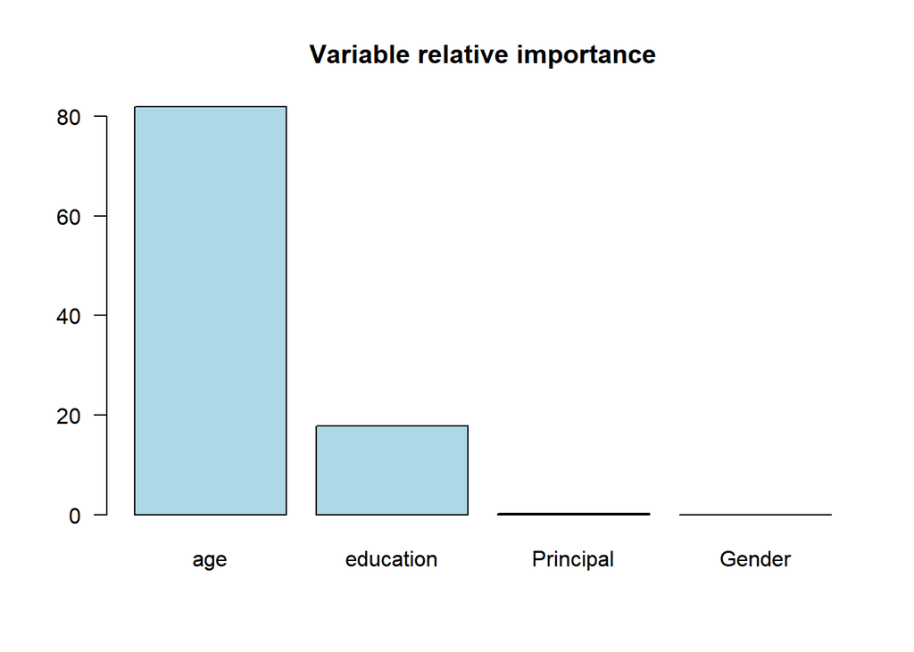

```r
importanceplot(loan_ada)
```

## 2번

2-(1) mfinal=70일 때의 boosting 함수를 만들어 준 뒤, tr_loan, te_loan을 이용해서 과적합 여부를 판단하세요.

```r
set.seed(300)
loan_ada2 = boosting(loan_status~., data=tr_loan, mfinal=70)
set.seed(300)
p_loan_ada2 = predict(loan_ada2, te_loan)
p_loan_ada2$error
```

```
## [1] 0.48
```

```r
set.seed(300)
tr_loan_ada2 = predict(loan_ada2, tr_loan)
tr_loan_ada2$error
```

```
## [1] 0.2857143
```

> 과적합!

2-(2) 그렇게 생각한 이유를 서술하시오.

> error가 20정도 차이나는 것으로 보아 과적합 됐다고 볼 수 있다.

## 3번

2번에서 본인이 판단한 것에 기반해 최적의 mfinal을 찾아 보세요.(for loop 사용) (mfinal의 70에서 +-5까지만 해주세요. 5이상이 넘어가면 시간이 너무 오래 걸립니다.) (2분만 기다리시면 결과가 나오니 기다려주세요.)

```r
errors=c()
for (i in -5:5){
  set.seed(300)
  ada = boosting(loan_status~., data=tr_loan, mfinal=70+i)
  tr_ada = predict(ada, tr_loan)
  p_ada = predict(ada, te_loan)
  errors = c(errors,tr_ada$error-p_ada$error)
}
errors
```

```
##  [1] -0.1819048 -0.1752381 -0.2009524 -0.2009524 -0.2009524 -0.1942857
##  [7] -0.1971429 -0.1933333 -0.2038095 -0.1933333 -0.1971429
```

```r
which.max(errors)
```

```
## [1] 2
```

> 최적의 i=-4일때므로 mfinal이 66일떄이다.